# Machine Learning Course Final Project

Jeff Wagg

27/05/2018

## Introduction

Using devices such as Jawbone Up, Nike FuelBand, and Fitbit it is now possible to collect a large amount of data about personal activity relatively inexpensively. These type of devices are part of the quantified self movement – a group of enthusiasts who take measurements about themselves regularly to improve their health, to find patterns in their behavior, or because they are tech geeks. One thing that people regularly do is quantify how much of a particular activity they do, but they rarely quantify how well they do it. In this project, the goal is to use data from accelerometers on the belt, forearm, arm, and dumbell of 6 participants. They were asked to perform barbell lifts correctly and incorrectly in 5 different ways. More information is available from the website here: http://groupware.les.inf.puc-rio.br/har (see the section on the Weight Lifting Exercise Dataset).

## Data

The training data for this project are available here:

https://d396qusza40orc.cloudfront.net/predmachlearn/pml-training.csv

The test data are available here:

https://d396qusza40orc.cloudfront.net/predmachlearn/pml-testing.csv

The data for this project come from this source: http://groupware.les.inf.puc-rio.br/har. If you use the document you create for this class for any purpose please cite them as they have been very generous in allowing their data to be used for this kind of assignment.

Begin by loading the required packages:

```r
library(caret)
library(lattice)
library(ggplot2)
library(randomForest)
library(rpart)
library(rpart.plot)
```

Here, we read in the training and testing datasets and clean the data:

```r
dtrain <- read.csv("/Users/j.wagg/DataScience/Course8/pml-training.csv",na.strings=c("NA","#DIV/0!", ""))
# explore the data
#summary(dtrain)
#colnames(dtrain)

dtest <- read.csv("/Users/j.wagg/DataScience/Course8/pml-testing.csv",na.strings=c("NA","#DIV/0!", ""))
# explore the data
#summary(dtest)
#colnames(dtest)

# Remove any columns with missing values
dtrain <- dtrain[,colSums(is.na(dtrain)) == 0]
dtest <- dtest[,colSums(is.na(dtest)) == 0]

cltrain <- grep("name|timestamp|window|X", colnames(dtrain), value=F)
dtrain <- dtrain[,-cltrain]
```

## Cross-validation of the data

We now split the training dataset up into two parts (70/30) in order to create the model and test it:

```r
set.seed(1234)

indextrain <- createDataPartition(y=dtrain$classe,p=0.70,list=F)
subtrain <- dtrain[indextrain,]
subtest <- dtrain[-indextrain,]
```

Plot the frequency of classes contained within the training dataset:

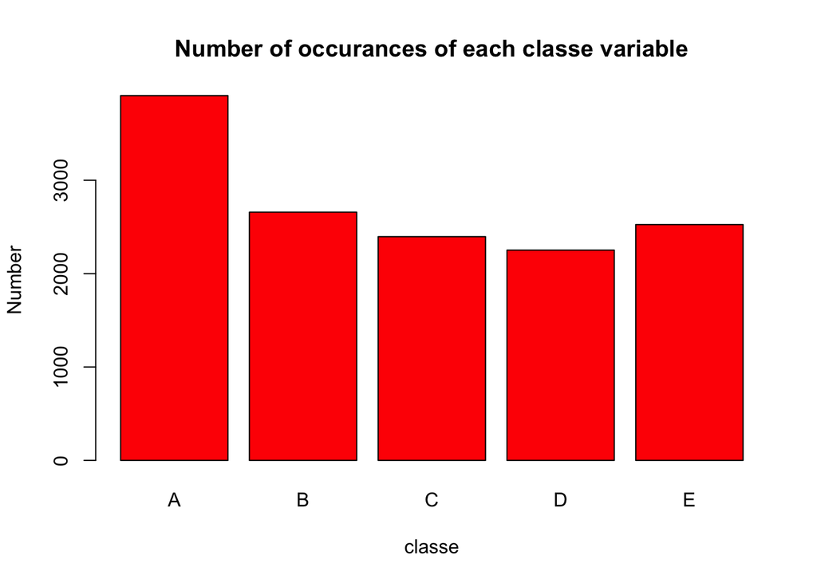

```r
plot(subtrain$classe, col="red", main="Number of occurances of each classe variable", xlab="classe", ylab="Number")
```

## Prediction models

We now generate two prediction models (Random forest and Decision tree) that we will later apply to the test data.

### Random forest

```r
forestmodel <- randomForest(subtrain$classe ~. , data=subtrain,dotrace=F,na.action=na.fail)
forestpredict <- predict(forestmodel, subtest)
confusionMatrix(forestpredict, subtest$classe)
```

```
## Confusion Matrix and Statistics
##
##           Reference
## Prediction    A    B    C    D    E
##          A 1674    8    0    0    0
##          B    0 1130    6    0    0
##          C    0    1 1019    5    0
##          D    0    0    1  958    1
##          E    0    0    0    1 1081
##
## Overall Statistics
##
##                Accuracy : 0.9961
##                  95% CI : (0.9941, 0.9975)
##     No Information Rate : 0.2845
##     P-Value [Acc > NIR] : < 2.2e-16
##
##                   Kappa : 0.9951
##  Mcnemar's Test P-Value : NA
##
## Statistics by Class:
##
##                      Class: A Class: B Class: C Class: D Class: E
## Sensitivity            1.0000   0.9921   0.9932   0.9938   0.9991
## Specificity            0.9981   0.9987   0.9988   0.9996   0.9998
## Pos Pred Value         0.9952   0.9947   0.9941   0.9979   0.9991
## Neg Pred Value         1.0000   0.9981   0.9986   0.9988   0.9998
## Prevalence             0.2845   0.1935   0.1743   0.1638   0.1839
## Detection Rate         0.2845   0.1920   0.1732   0.1628   0.1837
## Detection Prevalence   0.2858   0.1930   0.1742   0.1631   0.1839
## Balanced Accuracy      0.9991   0.9954   0.9960   0.9967   0.9994
```

### Decision tree

```r
treemodel <- rpart(subtrain$classe ~. , data=subtrain, method="class")
treepredict <- predict(treemodel, subtest, type = "class")
confusionMatrix(treepredict, subtest$classe)
```

```
## Confusion Matrix and Statistics
##
##           Reference
## Prediction    A    B    C    D    E
##          A 1364  169   24   48   16
##          B   60  581   46   79   74
##          C   52  137  765  129  145
##          D  183  194  125  650  159
##          E   15   58   66   58  688
##
## Overall Statistics
##
##                Accuracy : 0.6879
##                  95% CI : (0.6758, 0.6997)
##     No Information Rate : 0.2845
##     P-Value [Acc > NIR] : < 2.2e-16
##
##                   Kappa : 0.6066
##  Mcnemar's Test P-Value : < 2.2e-16
##
## Statistics by Class:
##
##                      Class: A Class: B Class: C Class: D Class: E
## Sensitivity            0.8148  0.51010   0.7456   0.6743   0.6359
## Specificity            0.9390  0.94543   0.9047   0.8657   0.9590
## Pos Pred Value         0.8415  0.69167   0.6230   0.4958   0.7774
## Neg Pred Value         0.9273  0.88940   0.9440   0.9314   0.9212
## Prevalence             0.2845  0.19354   0.1743   0.1638   0.1839
## Detection Rate         0.2318  0.09873   0.1300   0.1105   0.1169
## Detection Prevalence   0.2754  0.14274   0.2087   0.2228   0.1504
## Balanced Accuracy      0.8769  0.72776   0.8252   0.7700   0.7974
```

Based on these results, the random forest model performs much better than the decision tree model. The accuracy of the random forest model is over 99%, which is excellent.

## Application of the model to the testing data

To conclude, we now apply the random forest model to the testing data:

```r
finaltest <- predict(forestmodel, dtest,na.rm=TRUE)
finaltest
```

```
##  1  2  3  4  5  6  7  8  9 10 11 12 13 14 15 16 17 18 19 20
##  B  A  B  A  A  E  D  B  A  A  B  C  B  A  E  E  A  B  B  B
## Levels: A B C D E
```

## References

[1] Krzysztof Grabczewski and Norbert Jankowski. Feature Selection with Decision Tree Criterion.

[2] Velloso, E.; Bulling, A.; Gellersen, H.; Ugulino, W.; Fuks, H. Qualitative Activity Recognition of Weight Lifting Exercises. Proceedings of 4th International Conference in Cooperation with SIGCHI (Augmented Human ’13) . Stuttgart, Germany: ACM SIGCHI, 2013.